# BIOSTAT 620 HW 4

Author

Kyoka Ono

## HPC

For Questions 1-2, rewrite the provided R functions to make them faster. It is OK (and recommended) to take a look at StackOverflow and Google.

Using the synthetic dataset provided, show that your new function returns the same output as the original function. Then use `microbenchmark` to show that your version is faster and provide a visualization of the runtimes.

```r
library(microbenchmark)
library(parallel)
library(RSQLite)
library(DBI)
library(plotly)
library(ggplot2)
library(dplyr)
```

### Question 1 (6 points)

- `fun2`: Calculate the running (cumulative) total along each row of a numeric matrix. Output should be a matrix with dimensions equal to the input matrix.

```r
# running cumulative sum by row
fun2 <- function(mat) {
  n <- nrow(mat)
  k <- ncol(mat)
  ans <- mat
  for (i in 1:n) {
    for (j in 2:k) {
      ans[i,j] <- mat[i, j] + ans[i, j -  1]
    }
  }
  ans
}

fun2alt <- function(mat) {
  t(apply(mat, 1, cumsum))
}
```

Generate and test using the following synthetic data (`dat`):

```r
# Use the functions with this data
set.seed(2315)
dat <- matrix(rnorm(200 * 100), nrow = 200)
```

```r
fun2(dat)[1:5,1:5]
```

```
           [,1]        [,2]       [,3]        [,4]       [,5]
[1,]  0.7126079  1.51104243 -0.8676302  0.08029297 -0.1299293
[2,]  0.9312707  0.20179964 -0.2183219 -0.29083782 -1.4830381
[3,]  1.4957305  1.39766453  1.5288695  1.58880610 -2.1809434
[4,] -0.4397538  0.09986821 -0.1907445 -0.30679040 -0.1998791
[5,] -1.6066609 -2.31957952 -2.4765203 -2.23138767 -2.0026349
```

```r
fun2alt(dat)[1:5,1:5]
```

```
           [,1]        [,2]       [,3]        [,4]       [,5]
[1,]  0.7126079  1.51104243 -0.8676302  0.08029297 -0.1299293
[2,]  0.9312707  0.20179964 -0.2183219 -0.29083782 -1.4830381
[3,]  1.4957305  1.39766453  1.5288695  1.58880610 -2.1809434
[4,] -0.4397538  0.09986821 -0.1907445 -0.30679040 -0.1998791
[5,] -1.6066609 -2.31957952 -2.4765203 -2.23138767 -2.0026349
```

```r
microbenchmark(fun2(dat), fun2alt(dat))
```

```
Unit: microseconds
         expr      min       lq      mean    median        uq      max neval
    fun2(dat) 1212.083 1257.470 1330.5902 1305.7270 1372.2085 2031.796   100
 fun2alt(dat)  268.878  322.998  517.7214  341.7555  390.5045 8192.702   100
```

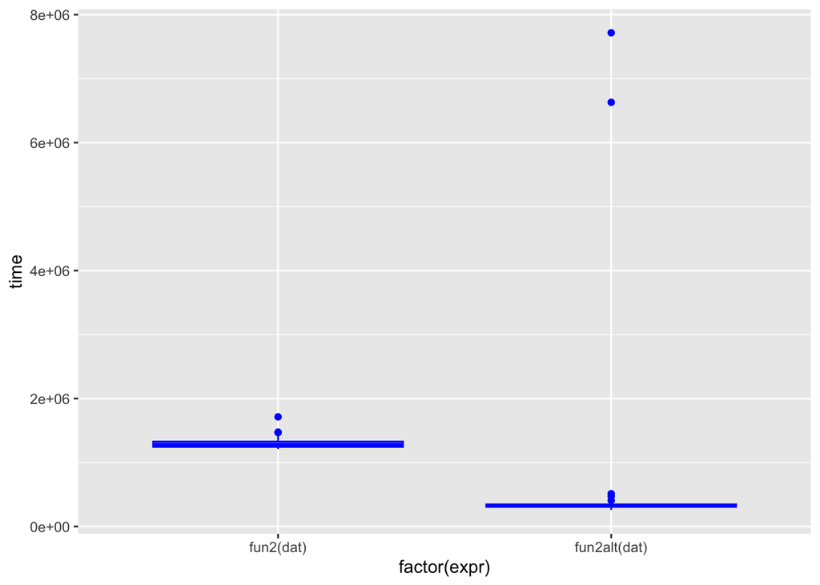

```r
ggplot(data = microbenchmark(fun2(dat), fun2alt(dat)),
       aes(x = factor(expr), y = time)) +
  geom_boxplot(color = "blue")
```

### Question 2 (8 points)

- `fun3`: Calculate the running (cumulative) total of a vector, where the sum resets when a zero is encountered.

```r
fun3 <- function(x) {
  out <- numeric(length(x))
  cumsum_x <- 0
  for (i in seq_along(x)) {
    if (x[i] == 0) {
      cumsum_x <- 0
    } else {
      cumsum_x <- cumsum_x + x[i]
    }
    out[i] <- cumsum_x
  }
  out
}
```

Generate your own synthetic datasets to test accuracy and speed.

```r
# testing accuracy
test_data <- c(1,3,4,
                5,7,0,
                3,7,4,
                4,2,7,
                9,4,0)

fun3(test_data)
```

```
 [1]  1  4  8 13 20  0  3 10 14 18 20 27 36 40  0
```

```r
funalt3 <- function(x) {
  out <- numeric(length(x))
  cumsum_x <- 0
  for (i in seq_along(x)) {
    val <- x[i]
    if (val == 0) {
      cumsum_x <- 0
    } else {
      cumsum_x <- cumsum_x + val
    }
    out[i] <- cumsum_x
  }
  out
}
```

```r
# testing speed
system.time(fun3(test_data))
```

```
   user  system elapsed
      0       0       0
```

```r
system.time(funalt3(test_data))
```

```
   user  system elapsed
  0.002   0.000   0.003
```

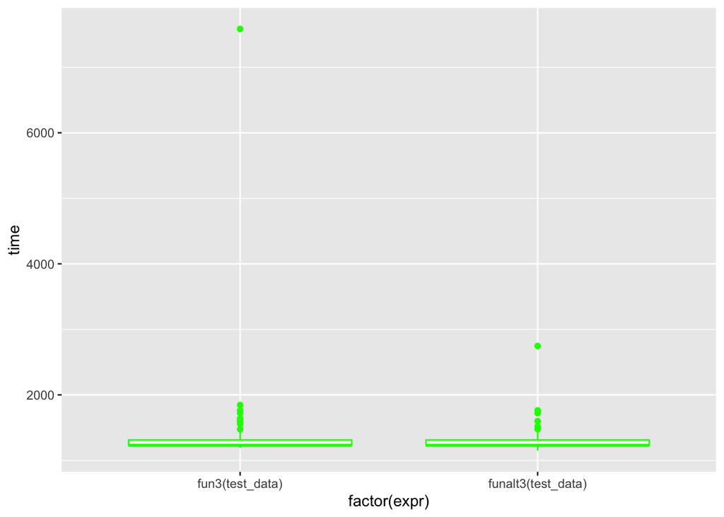

```r
ggplot(data = microbenchmark(fun3(test_data), funalt3(test_data)),
       aes(x = factor(expr), y = time)) +
  geom_boxplot(color = "green")
```

### Question 3 (12 points)

For this question, we will ask you to parallelize a process for computationally estimating the value of (pi).

The following function allows us to estimate $\pi$ through a simple simulation:

```r
sim_pi <- function(n = 1000, i = NULL) {
  p <- matrix(runif(n*2), ncol = 2)
  mean(rowSums(p^2) < 1) * 4
}

# Here is an example of the run
set.seed(156)
sim_pi(1000) # 3.132
```

```
[1] 3.132
```

In order to get more accurate estimates, we can run this function multiple times and take the mean:

```r
# This runs the simulation a 4,000 times, each with 10,000 points
set.seed(1231)

system.time({
  ans_non_parallel <- unlist(lapply(1:4000, sim_pi, n = 10000))
  print(mean(ans_non_parallel))
})
```

```
[1] 3.14124
```

```
   user  system elapsed
  0.797   0.209   1.037
```

```r
non_parallel<- system.time({
  ans_non_parallel <- unlist(lapply(1:4000, sim_pi, n = 10000))
  print(mean(ans_non_parallel))
})
```

```
[1] 3.142033
```

Rewrite the previous code using `parLapply()` (or your parallelization method of choice) to parallelize it. Run the code once, using `system.time()`, to show that your version is faster.

```r
# YOUR CODE HERE
system.time({
  cl <- makeCluster(7L)
  clusterExport(cl, "sim_pi")

  ans_parallel <- parLapply(cl = cl,
                   X = 1:4000,
                   fun = function(i){
                     sim_pi(1000)
                   })

  stopCluster(cl)

  ans_parallel <- do.call(rbind, ans_parallel)

  print(mean(ans_parallel))
})
```

```
[1] 3.141747
```

```
   user  system elapsed
  0.009   0.013   0.764
```

```r
parallel <- system.time({
  cl <- makeCluster(7L)
  clusterExport(cl, "sim_pi")

  ans_parallel <- parLapply(cl = cl,
                   X = 1:4000,
                   fun = function(i){
                     sim_pi(1000)
                   })

  stopCluster(cl)

  ans_parallel <- do.call(rbind, ans_parallel)

  print(mean(ans_parallel))
})
```

```
[1] 3.142482
```

Visualize your results in two ways:

1. Show that both versions produce similar ranges of estimates of $\pi$.
2. Show that the parallel versions runs faster.

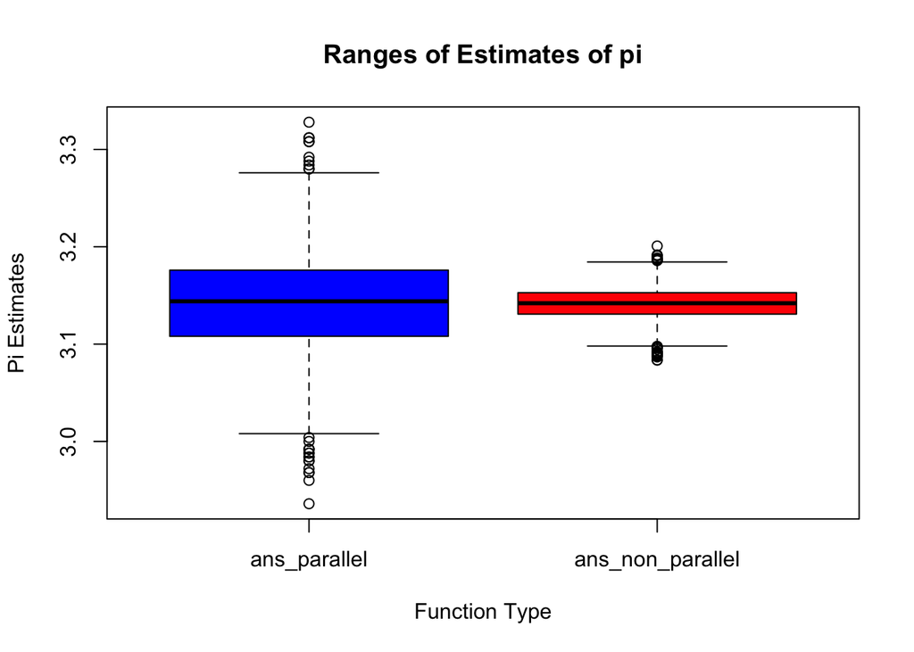

```r
pi_data <- data.frame(ans_parallel = ans_parallel,
                      ans_non_parallel = ans_non_parallel)

boxplot(pi_data,
        col = c("blue","red"),
        main = "Ranges of Estimates of pi",
        xlab = "Function Type",
        ylab = "Pi Estimates")
```

```r
non_parallel
```

```
   user  system elapsed
  0.918   0.245   1.294
```

```r
parallel
```

```
   user  system elapsed
  0.006   0.004   0.519
```

```r
timing <- data.frame(non_parallel = non_parallel,
                     parallel = parallel)
timing[1:3,]
```

[output not shown]

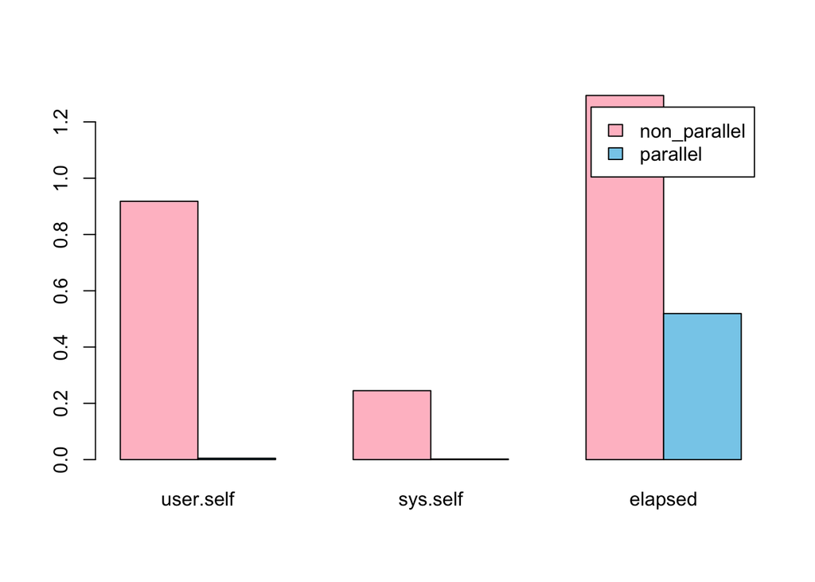

```r
barplot(t(as.matrix(timing[1:3,])),
        beside = TRUE,
        col = c("pink", "skyblue"),
        legend = colnames(timing))
```

## SQL

Dataset Description

The data we will be using is a time-series for a small mammal community in southern Arizona. This is part of a project studying the effects of rodents and ants on the plant community that has been running for almost 40 years. The rodents are sampled on a series of 24 plots, with different experimental manipulations controlling which rodents are allowed to access which plots.

Download data

You’ll need the following three files from this repository:

- `survey.csv`
- `species.csv`
- `plots.csv`

Setup a temporary database of ecology data by editing and running the following code chunk:

```r
# Initialize a temporary in memory database
con <- dbConnect(SQLite(), ":memory:")

# Read in tables
survey <- read.csv("/Users/kyokaono/Desktop/BIOSTAT620W26/surveys.csv")
species <- read.csv("/Users/kyokaono/Desktop/BIOSTAT620W26/species.csv")
plots <- read.csv("/Users/kyokaono/Desktop/BIOSTAT620W26/plots.csv")

# Copy data.frames to database
dbWriteTable(con, "survey", survey)
dbWriteTable(con, "species", species)
dbWriteTable(con, "plots", plots)
```

When you write a new chunk, remember to replace the `r` with `sql`, `connection=con`. Some of these questions will require you to use an inner join. Read more about them here

https://www.w3schools.com/sql/sql_join_inner.asp

Answer each of the questions below with SQL queries. Make sure to show the results of your queries.

### Question 4 (6 points)

First, using the approach from Lab 9, create a query to see the structure of the surveys table. Then, using the surveys table, write a query to display the three date fields, species_id, and weight in kilograms (rounded to two decimal places), for individuals captured in 1999, ordered alphabetically by the species_id.

```r
dbGetQuery(con,
           "PRAGMA table_info(survey)")
```

```
  cid            name    type notnull dflt_value pk
1   0       record_id INTEGER       0         NA  0
2   1           month INTEGER       0         NA  0
3   2             day INTEGER       0         NA  0
4   3            year INTEGER       0         NA  0
5   4         plot_id INTEGER       0         NA  0
6   5      species_id    TEXT       0         NA  0
7   6             sex    TEXT       0         NA  0
8   7 hindfoot_length INTEGER       0         NA  0
9   8          weight INTEGER       0         NA  0
```

```r
head(dbGetQuery(con,
           "SELECT year, month, day, species_id, ROUND(weight / 1000, 2) AS weight_kg
           FROM survey
           WHERE year = 1999
           ORDER BY species_id"))
```

```
  year month day species_id weight_kg
1 1999     1  17                   NA
2 1999     2  21                   NA
3 1999     2  21                   NA
4 1999     2  21                   NA
5 1999     3  15                   NA
6 1999     3  15                   NA
```

### Question 5 (6 points)

Write a query that returns: the total weight, average weight, minimum and maximum weights for all animals caught over the duration of the survey. Can you modify it so that it outputs these values only for weights between 5 and 10 inclusive?

```r
dbGetQuery(con,
           "SELECT SUM(weight) AS total_weight,
           AVG(weight) AS avg_weight,
           MIN(weight) AS min_weight,
           MAX(weight) AS max_weight
           FROM survey")
```

```
  total_weight avg_weight min_weight max_weight
1      1377594   42.67243          4        280
```

```r
dbGetQuery(con,
           "SELECT SUM(weight) AS total_weight,
           AVG(weight) AS avg_weight,
           MIN(weight) AS min_weight,
           MAX(weight) AS max_weight
           FROM survey
           WHERE weight >= 5 AND weight <= 10")
```

```
  total_weight avg_weight min_weight max_weight
1        24874   8.392038          5         10
```

### Question 6 (8 points)

Write a single query that returns:

1. How many were counted each year, for each different species
2. The average weights of each species in each year

Show the result and also store the resulting SQL data table as an R object. Hint, use the R function `DBI::dbGetQuery`. Note: to do so, you may need to, rather than running a SQL chunk, call SQL within an R chunk.

```r
# 1. How many were counted each year, for each different species
# 2. The average weights of each species in each year
head(dbGetQuery(con,
           "SELECT species_id, year, COUNT(species_id) AS count, weight, AVG(weight) AS ave_weight
           FROM survey
           GROUP BY species_id, year"))
```

```
  species_id year count weight ave_weight
1            1977    16     NA         NA
2            1978    56     NA         NA
3            1979    61     NA         NA
4            1980    40     NA         NA
5            1981    55     NA         NA
6            1982    14     NA         NA
```

### Question 7 (8 points)

Write a query that returns, from the species table, the number of species in each taxa, only for the taxa with more than 10 species.

```r
dbGetQuery(con,
"SELECT taxa, COUNT(*) AS taxa_count
FROM species
GROUP BY taxa
HAVING taxa_count > 10")
```

[output not shown]

### Question 8 (10 points)

Write a query that returns the number of animals caught of each genus in each plot. Order the results by plot number (ascending) and by descending number of individuals in each plot. Show the result and also store the resulting SQL data table as an R object.

```r
dim(survey)
```

```
[1] 35549     9
```

```r
dim(species)
```

```
[1] 54  4
```

```r
dim(plots)
```

```
[1] 24  2
```

```r
length(unique(survey$species_id))
```

```
[1] 49
```

```r
length(unique(species$species_id))
```

```
[1] 54
```

```r
merged_data <- dbGetQuery(con,
"SELECT a.*, b.genus, b.species, b.taxa, c.plot_type
FROM survey AS a LEFT JOIN species AS b
ON a.species_id = b.species_id
LEFT JOIN plots as c
ON a.plot_id = c.plot_id")

dim(merged_data)
```

```
[1] 35549    13
```

```r
dbWriteTable(con, "merged_data", merged_data)
```

```r
b <- dbGetQuery(con,
"SELECT plot_id, plot_type, genus, COUNT(*) AS count
FROM merged_data
GROUP BY genus, plot_id
ORDER BY plot_id ASC, count DESC")
```

### Question 9 (8 points)

How many specimens of each species were captured in each type of plot, excluding specimens of unknown species?

```r
head(dbGetQuery(con,
"SELECT plot_type, species, COUNT(species) AS species_count
FROM merged_data
WHERE species IS NOT NULL
GROUP BY species, plot_type"))
```

```
                  plot_type   species species_count
1                   Control  albigula           610
2  Long-term Krat Exclosure  albigula           166
3          Rodent Exclosure  albigula           147
4 Short-term Krat Exclosure  albigula           252
5         Spectab exclosure  albigula            77
6                   Control audubonii            29
```

### Question 10 (8 points)

Write a query that finds the average weight of each rodent species (i.e., only include species with Rodent in the taxa field).

```r
dbGetQuery(con,
"SELECT species, AVG(weight) AS weight_avg
FROM merged_data
WHERE taxa = 'Rodent'
GROUP BY species")
```

```
        species weight_avg
1      albigula 159.245660
2       baileyi  31.735943
3      eremicus  21.586508
4        flavus   7.923127
5    fulvescens  13.386667
6   fulviventer  58.878049
7       harrisi         NA
8      hispidus  65.563953
9   intermedius  19.250000
10  leucogaster  31.575258
11     leucopus  19.138889
12  maniculatus  21.364155
13    megalotis  10.585010
14     merriami  43.157864
15     montanus  10.250000
16 ochrognathus  55.414634
17        ordii  48.870523
18 penicillatus  17.173942
19          sp.  19.500000
20  spectabilis 120.130546
21    spilosoma  93.500000
22      taylori   8.600000
23 tereticaudus         NA
24     torridus  24.230556
```

### Question 11 (10 points)

Using `plotly::ggplotly` and the data table resultant from question 8, make an interactive grouped bar chart of the number of genus by plot id, subsetting to plot id 1-5.

```r
data <- dbGetQuery(con,
"SELECT plot_id, plot_type, genus, COUNT(*) AS count
FROM merged_data
GROUP BY genus, plot_type
ORDER BY plot_id ASC, count DESC")

dbWriteTable(con, "data", data)
```

```r
c <- b %>% filter(plot_id %in% 1:5)
p <- ggplot(data = c, mapping = aes(x = factor(plot_id), y = count, fill = genus)) +
  geom_bar(stat = "identity", position = "dodge") +
  labs(x = "Plot ID", y = "Count")
  labs(title = "Number of Genus by Plot ID") +
  theme(plot.title = element_text(hjust = 0.5))
```

```r
ggplotly(p)
```

[interactive chart not shown]

### Question 12 (10 points)

Using native `plotly` functions (no `ggplot2`) and the data table resultant from question 6, make an interactive line chart of average species weight over time for each species. Make sure to properly handle missing data. Can you do anything to reduce the noise in your plot?

```r
data_2 <- dbGetQuery(con,
           "SELECT species_id, year, COUNT(species_id) AS count, weight, AVG(weight) AS ave_weight
           FROM survey
           WHERE weight IS NOT NULL
           GROUP BY species_id, year")

dbWriteTable(con, "data_2", data_2)
```

```r
plot_ly(data_2,
       x = ~year,
       y = ~ave_weight,
       color = ~species_id,
       type = "scatter",
       mode = "lines",
       hoverinfo = "text",
       text = ~paste(paste(species_id, ":", sep = ""),
                     paste("Year: ", year, sep = ""),
                     paste(" Average Weight: ", ave_weight, sep = ""),
                           sep = "<br>"))
```

[interactive chart not shown]

```r
data_3 <- dbGetQuery(con,
           "SELECT species_id, year, COUNT(species_id) AS count, weight, AVG(weight) AS ave_weight
           FROM survey
           WHERE weight IS NOT NULL
           GROUP BY species_id, year
           HAVING count > 20")

dbWriteTable(con, "data_3", data_3)
```

```r
plot_ly(data_3,
       x = ~year,
       y = ~ave_weight,
       color = ~species_id,
       type = "scatter",
       mode = "lines",
       hoverinfo = "text",
       text = ~paste(paste(species_id, ":", sep = ""),
                     paste("Year: ", year, sep = ""),
                     paste(" Average Weight: ", ave_weight, sep = ""),
                           sep = "<br>"))
```

[interactive chart not shown]